# 607 Final Project

Author

Dylan Gold

# Approach

For this project I will be collecting data on video game sales as well as video game reviews and seeing how factors like game sales and genre affect video game reviews.  
I will limit the scope to finding a correlation/relationship between the sales a videogame has and the reviews it gets from Rawg.io

# Collecting Data

To start this project we need to first collect the data.  
I have chosen two data sources one is a csv from https://www.kaggle.com/datasets/volodymyrpivoshenko/video-game-sales-dataset  
The other is using an api of a gaming review website rawg.io. This is a link to their api documentation https://api.rawg.io/docs/#tag/developers

First I will collect the data from the csv. This will serve as our base data that we will use to query the api.

```r
library(tidyverse)
library(httr)
library(jsonlite)
library(stringi)
```

```r
url <- "https://raw.githubusercontent.com/DylanGoldJ/607-Final-Project/refs/heads/main/video_games_sales.csv"

df <- read_csv(
  file = url,
  col_names = TRUE
)


head(df, 5)
```

```
# A tibble: 5 × 11
   Rank Name           Platform Year  Genre Publisher NA_Sales EU_Sales JP_Sales
  <dbl> <chr>          <chr>    <chr> <chr> <chr>        <dbl>    <dbl>    <dbl>
1     1 Wii Sports     Wii      2006  Spor… Nintendo      41.5    29.0      3.77
2     2 Super Mario B… NES      1985  Plat… Nintendo      29.1     3.58     6.81
3     3 Mario Kart Wii Wii      2008  Raci… Nintendo      15.8    12.9      3.79
4     4 Wii Sports Re… Wii      2009  Spor… Nintendo      15.8    11.0      3.28
5     5 Pokemon Red/P… GB       1996  Role… Nintendo      11.3     8.89    10.2
# ℹ 2 more variables: Other_Sales <dbl>, Global_Sales <dbl>
```

Now I also need to collect data from the api.  
I will start with a simple example.  
First I will load in my key

```r
api_key <- Sys.getenv("RAWGIO_API_KEY") # Load api key from envrionment.
```

Because the api has way more total games than our data set we will query the data set for each game individually.  
First I will try to get Wii Sports game info from the api.

```r
api_url <- "https://api.rawg.io/api/games"

response <- GET(
  api_url,
  query = list(
    key = api_key, # Api key
    search = "Wii Sports" # Wii sports as our testing value.
  )
)

status_code(response)
```

```
[1] 200
```

We got a sucessful response. Now I will extract the data from the response

```r
data <- fromJSON(content(response, "text", encoding = "UTF-8"))
game_review <- data$results
head(game_review)
```

```
                             slug                              name playtime
1                      wii-sports                        Wii Sports       55
2               wii-sports-resort                 Wii Sports Resort        2
3 pokepark-wii-pikachus-adventure PokePark Wii: Pikachu's Adventure        0
4                 wii-sports-itch                 Wii sports (itch)        0
5                 wii-sports-club                   Wii Sports Club       21
6                 e-sport-manager                   E-Sport Manager        1
                                       platforms
1                                   11, Wii, wii
2                                   11, Wii, wii
3                                   11, Wii, wii
4                                  171, Web, web
5                               10, Wii U, wii-u
6 4, 7, PC, Nintendo Switch, pc, nintendo-switch
                                        stores   released   tba
```

[output cut: 104 more lines]

We can see that we were given a list of games that match the search query. The top match Wii Sports is exactly what we searched for.  
We can also see that the second game from this search is also the 4th ranked game on our games sold data frame.  
There will be times when we get multiple games from a search query that are in our games sold data frame.  
To minimize the number of requests (I have only 20,000 this month) I will try to fill in this data as well from each search.

This was a challenge I had, making sure to not waste my limited requests. Initially my plan was to search each game one at a time. While I may have had enough requests to do this it would be a lot slower as well as waste requests that I may need for the future.  
Because the search was not an exact match, we can get values that we did not search directly which helps maintain our query limit.

First I will make a function that takes the values from the request for the game and binds them to the original data frame with a left join.

```r
game_data <- df # Copy of df to work on

# Make new columns in game_data

# This function will take the sold df and the reviews df and fill in columns for the game_data df based on the df_reviews.
combine_data <- function(df, df_reviews){
  # Select columns from reviews that we want to add.
  head(df_reviews)
  df_reviews <- df_reviews %>% select( # Select different rating to use, `rating` seems to be the main one.
    Name = name,
    rating,
    rating_top,
    metacritic,
    score,
    ratings_count
  )

  combined <- left_join(df, df_reviews, by = "Name")
  return(combined)
}
combined_wii <- combine_data(game_data, game_review)
head(combined_wii)
```

```
# A tibble: 6 × 16
   Rank Name           Platform Year  Genre Publisher NA_Sales EU_Sales JP_Sales
  <dbl> <chr>          <chr>    <chr> <chr> <chr>        <dbl>    <dbl>    <dbl>
1     1 Wii Sports     Wii      2006  Spor… Nintendo      41.5    29.0      3.77
2     2 Super Mario B… NES      1985  Plat… Nintendo      29.1     3.58     6.81
3     3 Mario Kart Wii Wii      2008  Raci… Nintendo      15.8    12.9      3.79
4     4 Wii Sports Re… Wii      2009  Spor… Nintendo      15.8    11.0      3.28
5     5 Pokemon Red/P… GB       1996  Role… Nintendo      11.3     8.89    10.2
6     6 Tetris         GB       1989  Puzz… Nintendo      23.2     2.26     4.22
# ℹ 7 more variables: Other_Sales <dbl>, Global_Sales <dbl>, rating <dbl>,
#   rating_top <int>, metacritic <int>, score <chr>, ratings_count <int>
```

We can see that there are several columns that got filled in below is some of the values

```r
head(combined_wii %>% filter(!is.na(rating))) # Check rows with a rating
```

```
# A tibble: 6 × 16
   Rank Name           Platform Year  Genre Publisher NA_Sales EU_Sales JP_Sales
  <dbl> <chr>          <chr>    <chr> <chr> <chr>        <dbl>    <dbl>    <dbl>
1     1 Wii Sports     Wii      2006  Spor… Nintendo     41.5     29.0      3.77
2     3 Mario Kart Wii Wii      2008  Raci… Nintendo     15.8     12.9      3.79
3     4 Wii Sports Re… Wii      2009  Spor… Nintendo     15.8     11.0      3.28
4     8 Wii Play       Wii      2006  Misc  Nintendo     14.0      9.2      2.93
5     9 New Super Mar… Wii      2009  Plat… Nintendo     14.6      7.06     4.7
6    14 Wii Fit        Wii      2007  Spor… Nintendo      8.94     8.03     3.6
# ℹ 7 more variables: Other_Sales <dbl>, Global_Sales <dbl>, rating <dbl>,
#   rating_top <int>, metacritic <int>, score <chr>, ratings_count <int>
```

Now I will make a function that can get the api request data given the search term.  
It will return the data frame with the data or null if the request is bad

```r
search_api <- function(query){

api_url <- "https://api.rawg.io/api/games"

response <- GET(
  api_url,
  query = list(
    key = api_key, # Api key
    search = query # Wii sports as our testing value.
  )
)

if (status_code(response) == 200){
  data <- fromJSON(content(response, "text", encoding = "UTF-8"))
  game_review <- data$results
  return(game_review)
  }
return(NULL) # If we have a bad response return null
}
```

I will test this function on a popular series Call of Duty. I will search for a specific game “Call of Duty: Black Ops”

```r
cod_response_df <- search_api("Call of Duty: Black Ops")
head(cod_response_df)
```

```
                             slug                             name playtime
1          call-of-duty-black-ops          Call of Duty: Black Ops        9
2        call-of-duty-black-ops-6        Call of Duty: Black Ops 6        0
3        call-of-duty-black-ops-7        Call of Duty: Black Ops 7        0
4                cod-black-ops-ii       Call of Duty: Black Ops II        5
5               cod-black-ops-iii      Call of Duty: Black Ops III       16
6 call-of-duty-black-ops-cold-war Call of Duty: Black Ops Cold War       11
                                                                                                                                                          platforms
1 4, 1, 3, 9, 5, 14, 16, 11, PC, Xbox One, iOS, Nintendo DS, macOS, Xbox 360, PlayStation 3, Wii, pc, xbox-one, ios, nintendo-ds, macos, xbox360, playstation3, wii
2                                                                                  4, 187, 186, PC, PlayStation 5, Xbox Series S/X, pc, playstation5, xbox-series-x
3                                                                                  4, 187, 186, PC, PlayStation 5, Xbox Series S/X, pc, playstation5, xbox-series-x
4                                                        4, 1, 14, 16, 10, PC, Xbox One, Xbox 360, PlayStation 3, Wii U, pc, xbox-one, xbox360, playstation3, wii-u
5                                         4, 1, 18, 14, 16, PC, Xbox One, PlayStation 4, Xbox 360, PlayStation 3, pc, xbox-one, playstation4, xbox360, playstation3
6                          4, 187, 1, 18, 186, PC, PlayStation 5, Xbox One, PlayStation 4, Xbox Series S/X, pc, playstation5, xbox-one, playstation4, xbox-series-x
                                                                                                                             stores
```

[output cut: 104 more lines]

I wanted to look at how this game shows up in our combined data.

```r
combined_data <- combined_wii

cod_sales <- combined_data %>%
  filter(str_detect(Name, "Call of Duty"))
head(cod_sales)
```

```
# A tibble: 6 × 16
   Rank Name           Platform Year  Genre Publisher NA_Sales EU_Sales JP_Sales
  <dbl> <chr>          <chr>    <chr> <chr> <chr>        <dbl>    <dbl>    <dbl>
1    30 Call of Duty:… X360     2011  Shoo… Activisi…     9.03     4.28     0.13
2    32 Call of Duty:… X360     2010  Shoo… Activisi…     9.67     3.73     0.11
3    34 Call of Duty:… PS4      2015  Shoo… Activisi…     5.77     5.81     0.35
4    35 Call of Duty:… PS3      2012  Shoo… Activisi…     4.99     5.88     0.65
5    36 Call of Duty:… X360     2012  Shoo… Activisi…     8.25     4.3      0.07
6    37 Call of Duty:… X360     2009  Shoo… Activisi…     8.52     3.63     0.08
# ℹ 7 more variables: Other_Sales <dbl>, Global_Sales <dbl>, rating <dbl>,
#   rating_top <int>, metacritic <int>, score <chr>, ratings_count <int>
```

We can combine these like we did before with the Wii sports games.  
This time the columns are already created so we have to also coalesce the data frames.  
I will update the function I made to do this.  
If we were doing it one by one we could combine it all in one step but I wanted a way that made the data frame step by step.

```r
# Update the function to handle the columns already being present.
combine_data <- function(df, df_reviews){
  # Select columns from reviews that we want to add.
  head(df_reviews)
  df_reviews <- df_reviews %>% select( # Select different rating to use, `rating` seems to be the main one.
    Name = name,
    rating,
    rating_top,
    metacritic,
    score,
    ratings_count
  )

  combined <- left_join(df, df_reviews, by = "Name") %>%
  mutate(
    rating = coalesce(rating.x, rating.y), # Because the dataframe already has these columns we can coalesce. This will take the non na value.
    rating_top = coalesce(rating_top.x, rating_top.y),
    metacritic = coalesce(metacritic.x, metacritic.y),
    score = coalesce(score.x, score.y),
    ratings_count = coalesce(ratings_count.x, ratings_count.y)
    ) %>%
  select(-ends_with(".x"), -ends_with(".y")) # Remove the .x and .y columns. These are the duplicates from the original left_join
  return(combined)
}

combined_data <- combine_data(combined_data, cod_response_df)
(combined_data %>% filter(!is.na(rating) &  (str_detect(Name, "Call of Duty"))))  # Show the cod games that were filled
```

```
# A tibble: 9 × 16
   Rank Name           Platform Year  Genre Publisher NA_Sales EU_Sales JP_Sales
  <dbl> <chr>          <chr>    <chr> <chr> <chr>        <dbl>    <dbl>    <dbl>
1    32 Call of Duty:… X360     2010  Shoo… Activisi…     9.67     3.73     0.11
2    35 Call of Duty:… PS3      2012  Shoo… Activisi…     4.99     5.88     0.65
3    36 Call of Duty:… X360     2012  Shoo… Activisi…     8.25     4.3      0.07
4    41 Call of Duty:… PS3      2010  Shoo… Activisi…     5.98     4.44     0.48
5  1128 Call of Duty:… PC       N/A   Shoo… Activisi…     0.58     0.81     0
6  1219 Call of Duty:… PC       2012  Shoo… Activisi…     0.63     0.69     0
7  1381 Call of Duty:… Wii      2010  Shoo… Activisi…     0.82     0.47     0
8  3213 Call of Duty:… DS       2010  Shoo… Activisi…     0.54     0.05     0
9  4556 Call of Duty:… WiiU     2012  Shoo… Activisi…     0.21     0.18     0
# ℹ 7 more variables: Other_Sales <dbl>, Global_Sales <dbl>, rating <dbl>,
#   rating_top <int>, metacritic <int>, score <chr>, ratings_count <int>
```

While looking at the data I notice that not all of the Call of Duty games from the reviews have matches to our sales data.  
It is entirely possible that these data sets do not have complete overlap. I will leave these values as NA. If we have enough data I will leave it like this.

Now I want to iterate through the data frame based on null ratings.  
I used the latest free version of chat gpt to help generate this code.  
This code keeps track of the already tried rows

```r
attempted_ids <- character() # Keep track of attempted names
```

Now perform the api calls, cache = true keeps the results in memory for the knit.

```r
remaining_ids <- combined_data %>% # Get the names that still need to be tried
  filter(is.na(rating)) %>% # Rows that have no rating
  distinct(Name) # No need to run the same game twice(its separated by Platform)

while(nrow(remaining_ids) > 0) { # while we have remaining ids

  id <- remaining_ids$Name[1] # Get the name as id

  # mark as attempted BEFORE api call
  attempted_ids <- c(attempted_ids, id) # Update attempted_ids with the extra name

  api_result <- search_api(id) # Search for the name

  # print(id) Testing, seeing which is the last item that causes an error

  # update data frame
  if (!is.null(api_result)) {
    if(length(api_result) != 0) # Check empty/na api_result
      combined_data <- combine_data(combined_data, api_result)
}

  # only unresolved AND unattempted ids
  remaining_ids <- combined_data %>%
    filter(is.na(rating)) %>%
    distinct(Name) %>%
    filter(!Name %in% attempted_ids) #Names that are not attempted
}
```

We can check which ratings are still null

```r
combined_null <- combined_data %>% filter(is.na(rating)) # Check rows with no rating
nrow(combined_null)
```

```
[1] 6679
```

```r
head(combined_null)
```

```
# A tibble: 6 × 16
   Rank Name           Platform Year  Genre Publisher NA_Sales EU_Sales JP_Sales
  <dbl> <chr>          <chr>    <chr> <chr> <chr>        <dbl>    <dbl>    <dbl>
1     5 Pokemon Red/P… GB       1996  Role… Nintendo     11.3      8.89    10.2
2     6 Tetris         GB       1989  Puzz… Nintendo     23.2      2.26     4.22
3    10 Duck Hunt      NES      1984  Shoo… Nintendo     26.9      0.63     0.28
4    11 Nintendogs     DS       2005  Simu… Nintendo      9.07    11        1.93
5    13 Pokemon Gold/… GB       1999  Role… Nintendo      9        6.18     7.2
6    20 Brain Age: Tr… DS       2005  Misc  Nintendo      4.75     9.26     4.16
# ℹ 7 more variables: Other_Sales <dbl>, Global_Sales <dbl>, rating <dbl>,
#   rating_top <int>, metacritic <int>, score <chr>, ratings_count <int>
```

We can also check the ratings that got values

```r
combined_filled <- combined_data %>% filter(!is.na(rating))
nrow(combined_filled)
```

```
[1] 9919
```

```r
head(combined_filled)
```

```
# A tibble: 6 × 16
   Rank Name           Platform Year  Genre Publisher NA_Sales EU_Sales JP_Sales
  <dbl> <chr>          <chr>    <chr> <chr> <chr>        <dbl>    <dbl>    <dbl>
1     1 Wii Sports     Wii      2006  Spor… Nintendo      41.5    29.0      3.77
2     2 Super Mario B… NES      1985  Plat… Nintendo      29.1     3.58     6.81
3     3 Mario Kart Wii Wii      2008  Raci… Nintendo      15.8    12.9      3.79
4     4 Wii Sports Re… Wii      2009  Spor… Nintendo      15.8    11.0      3.28
5     7 New Super Mar… DS       2006  Plat… Nintendo      11.4     9.23     6.5
6     8 Wii Play       Wii      2006  Misc  Nintendo      14.0     9.2      2.93
# ℹ 7 more variables: Other_Sales <dbl>, Global_Sales <dbl>, rating <dbl>,
#   rating_top <int>, metacritic <int>, score <chr>, ratings_count <int>
```

Now that I have the data,, and I still want the data to be accessible and reproducible I will save the data to a csv.

```r
write.csv(combined_data, "combined_data.csv", row.names = TRUE)
```

# Cleaning Data

We can see that much of our data is filled in. There are a lot of rows that are still NA. This could be for several reasons like mismatching names or just the lack of a review for that specific game. I tried a little fixing initially but it seemed inconsequential to fix specific game names and such. To fix this problem I will just drop these values.  
I will focus on the rating column. According to the api this is the column that can not be NA in the response and is the main rating.

```r
cleaned_df <- combined_data %>%
  filter(!is.na(rating))
```

Now I will pivot longer based on the sales rows

```r
cleaned_df <- cleaned_df %>%
  pivot_longer(
    cols = ends_with("_Sales"), # The columns that end in _Sales
    names_to = "Region",
    names_pattern = "(.*)_Sales", # Get the grouping for the Region.
    values_to = "Sales"
  )
head(cleaned_df)
```

```
# A tibble: 6 × 13
   Rank Name   Platform Year  Genre Publisher rating rating_top metacritic score
  <dbl> <chr>  <chr>    <chr> <chr> <chr>      <dbl>      <int>      <int> <chr>
1     1 Wii S… Wii      2006  Spor… Nintendo    4.21          4         76 72.3…
2     1 Wii S… Wii      2006  Spor… Nintendo    4.21          4         76 72.3…
3     1 Wii S… Wii      2006  Spor… Nintendo    4.21          4         76 72.3…
4     1 Wii S… Wii      2006  Spor… Nintendo    4.21          4         76 72.3…
5     1 Wii S… Wii      2006  Spor… Nintendo    4.21          4         76 72.3…
6     2 Super… NES      1985  Plat… Nintendo    4.32          4         NA 96.5…
# ℹ 3 more variables: ratings_count <int>, Region <chr>, Sales <dbl>
```

We can also select the columns that we want to work with. I will take just the rating and metacritic for the rating values. Metacritic is sometimes NA

```r
cleaned_df <- cleaned_df %>%
  select(Rank, Name, Platform, Year, Genre, Publisher, Region, Sales, Rating = rating, Metacritic = metacritic )
head(cleaned_df)
```

```
# A tibble: 6 × 10
   Rank Name       Platform Year  Genre Publisher Region Sales Rating Metacritic
  <dbl> <chr>      <chr>    <chr> <chr> <chr>     <chr>  <dbl>  <dbl>      <int>
1     1 Wii Sports Wii      2006  Spor… Nintendo  NA     41.5    4.21         76
2     1 Wii Sports Wii      2006  Spor… Nintendo  EU     29.0    4.21         76
3     1 Wii Sports Wii      2006  Spor… Nintendo  JP      3.77   4.21         76
4     1 Wii Sports Wii      2006  Spor… Nintendo  Other   8.46   4.21         76
5     1 Wii Sports Wii      2006  Spor… Nintendo  Global 82.7    4.21         76
6     2 Super Mar… NES      1985  Plat… Nintendo  NA     29.1    4.32         NA
```

# Analyzing Data

Now that the data is in a tidy format with information we want we can now start to analyze it.  
Our initial question was trying to find a correlation between Sales amount and ratings.  
I will filter for the global region and graph sales vs rating.  
I also tried adjusting the alpha value due to the high overlap of points.

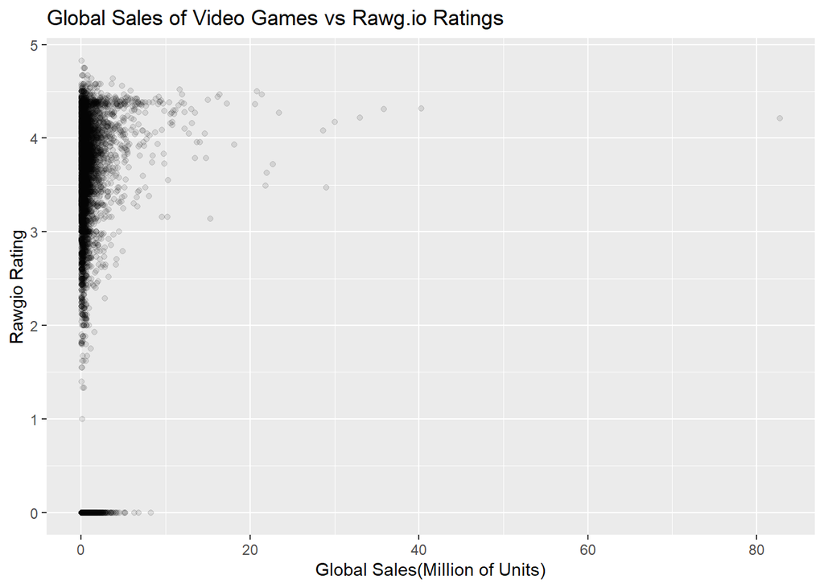

```r
global_df <- cleaned_df %>%
  filter(Region == "Global")

ggplot(global_df, aes(x = Sales, y = Rating)) +
  geom_point(alpha = 0.1) +
  labs(
    title = "Global Sales of Video Games vs Rawg.io Ratings",
    x = "Global Sales(Million of Units)",
    y = "Rawgio Rating"
  )
```

We also notice that there are a lot of games that got a review of 0. I am not sure whether or not these values are intentional or not. It may depend on the game.  
We can see that all games that have more than 10 million sales do not have a rating lower than 3. Games that are rating less than 3 are all games that have less than 10 million global sales. I will remove the 0 rated games.

```r
cleaned_zero_removed <- cleaned_df %>%
  filter(Rating > 0)
```

Now the global graph again

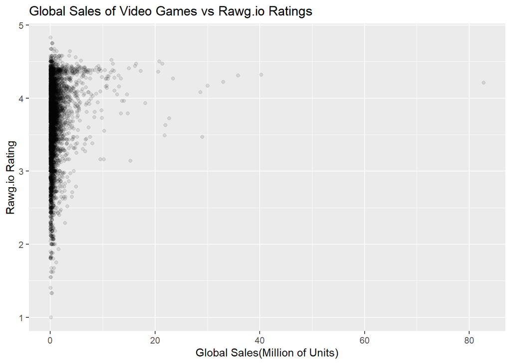

```r
global_df <- cleaned_zero_removed %>%
  filter(Region == "Global")

ggplot(global_df, aes(x = Sales, y = Rating)) +
  geom_point(alpha = 0.1) +
  labs(
    title = "Global Sales of Video Games vs Rawg.io Ratings",
    x = "Global Sales(Million of Units)",
    y = "Rawg.io Rating"
  )
```

We can see in the graph above that most games have less than 10 million sales and games tend to be rated higher

[figure not shown]

```r
NA_df <- cleaned_zero_removed %>%
  filter(Region == "NA")

ggplot(global_df, aes(x = Sales, y = Rating)) +
  geom_point(alpha = 0.1) +
  labs(
    title = "North America Sales of Video Games vs Rawg.io Ratings",
    x = "NA Sales(Million of Units)",
    y = "Rawg.io Rating"
  )
```

While there seems to be a positive correlation between sales and reviews we can use statistical methods in R to actually find the correlation. I will go back to using the global dataset.

```r
cor(global_df$Sales, global_df$Rating)
```

```
[1] 0.164879
```

We get a correlation of .16 when using the default correlation in R (pearson) This is a weak but positive correlation.  
Higher game sales can slightly be associated with a higher Rawg.io rating  
This may not be the best method given we have some outliers.

Below is a graph with a linear model attached because so much of the data is clustered at the start this is not very helpful because of this.

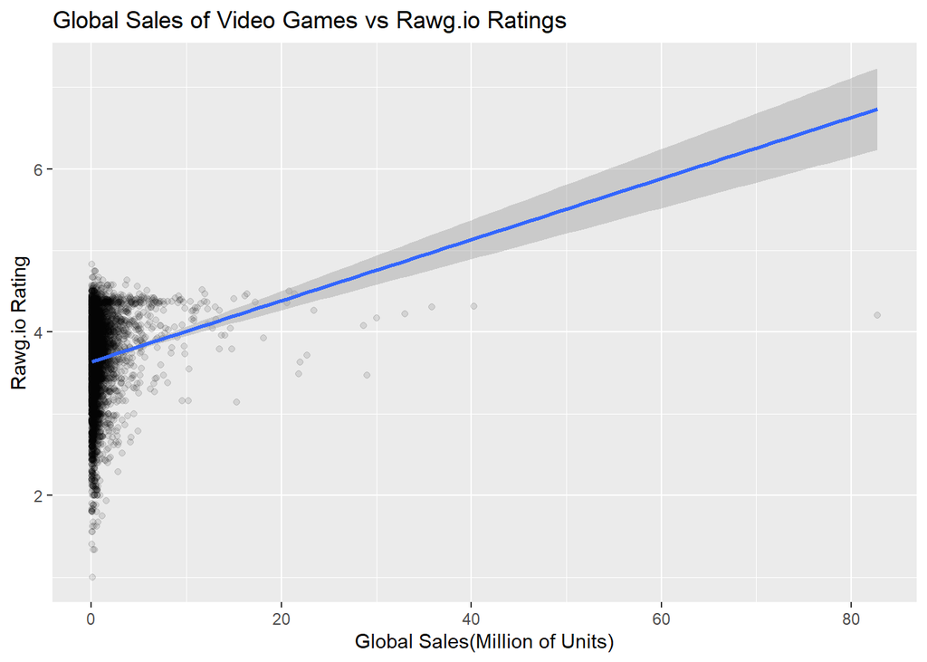

```r
ggplot(global_df, aes(x = Sales, y = Rating)) +
  geom_point(alpha = 0.1) +
  geom_smooth(method = "lm") +
  labs(
    title = "Global Sales of Video Games vs Rawg.io Ratings",
    x = "Global Sales(Million of Units)",
    y = "Rawg.io Rating"
  )
```

Because we have some outliers we can use Spearman to also create a correlation.  
Spearman looks at the rank of the data rather than the raw values. This makes better for when we have large outliers and such. When doing this we still get a slightly positive correlation. This is something we did not cover but does a good job for this set of data.

```r
cor(global_df$Sales, global_df$Rating, method = "spearman", use = "complete.obs")
```

```
[1] 0.2027387
```

Spearman correlation does not give us a representation of the linearity of the data but whether or not the data has an increasing/decreasing trend. This correlation would indicate that there is a slight trend that as the Sales of a game increases, that the rating (from rawg.io) also increases. This makes sense as popular games tend to be rated higher. I am little surprised that the correlation was not higher though.

# Conclusion

In conclusion we were able to extract data from a csv and from a public API to determine a relationship between game sales and game reviews from the api Rawg.io.  
We had issues with our limited query amounts and the time it took but we were able to solve those issues by dynamically filling multiple rows in our dataframe with each api call.  
After collecting the data we turned it into a tidy data set with pivot longer and dropping rows that did not get filled in properly.  
We then graphed the data based on the global region(all regions) and saw trends that would indicate a positive correlation between sales and reviews. We also used a new correlation, Spearman Correlation to see if our data had an increasing trend. Due to the outliers in our data it made sense to use this type of correlation over pearson or kendall. With this we saw a positive correlation and we can conclude that there is a slighly positive trend in that higher video game sales tend to have higher reviews on Rawg.io.